# Efficiency and Markets

## Pregame

- I’ll upload midterm grades Tuesday by 12pm.
- Wednesday writing assignment is due by 5pm!
- Extra credit opportunity: tonight (10/08) at 5:30pm in the Ensminger Pavilion. I’ll be there to talk about Peace Corps!

## Writing Assignment 2

The situation:

- No, not [that situation](http://entertainment.ie/celebrity-gossip/Mike-The-Situation-from-Jersey-Shore-sentenced-to-8-months-in-jail-for-tax-evasion/408819.htm).
- Three markets: Gasoline, fast food, and home improvement.
- [The article](https://www.thestreet.com/investing/rising-gas-prices-wont-hurt-retailers-for-now-14588845) suggests that consumers of gas have two different elasticities depending on the price point.
  - what are those elasticities (i.e. which section is relatively inelastic and which is relatively elastic)?
  - what is the price point at which the demand curve becomes more (in)elastic?
  - which part of the demand curve is the price at now?
  - how does this affect fast food and home improvement? Are they compliments or substitutes?
  - how does this affect online retail?

## Nobel Prize in Economics

## Nobel Prize in Economics 2018

[interactive chart not shown]

[via GIPHY](https://giphy.com/gifs/see-heavy-aQYR1p8saOQla)

## Nobel Prize in Economics 2018

- Paul Romer ([twitter](https://twitter.com/paulmromer), [website](https://paulromer.net/)) - How innovation affects growth.
- William Nordhaus ([website](https://sites.google.com/site/williamdnordhaus/papers_speeches)) - Economic effects of climate.

## Romer’s charter cities

The problem:

- Worldwide there are lots of people who don’t own land, so there is increasing immigration.

If we want equal treatment and we want democracy, the solution is difficult because *enforcing borders is expensive and not particularly effective*.

## Romer’s charter cities

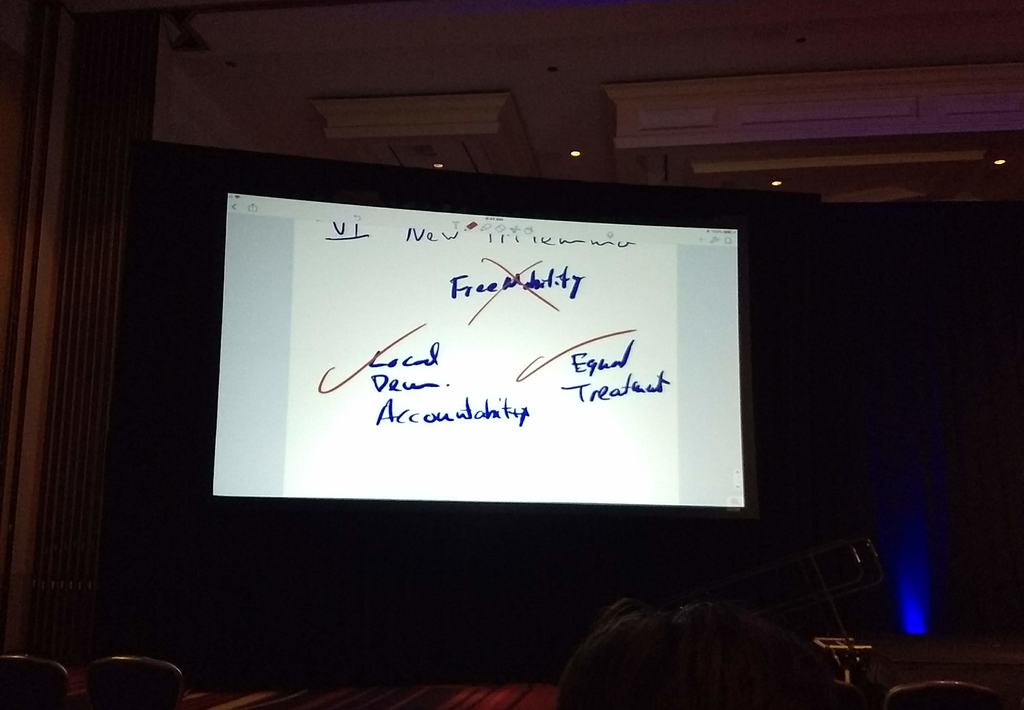

## Romer’s charter cities

- If we want free mobility: people move in with different cultures and norms, we lose either equal treatment (if people are from a society that does not value gender equality) or democracy (if people are from a non-democratic society).
- If we want democracy: have to either restrict free mobility or restrict the ability of immigrants to vote, so we lose equal treatment.
- If we want equal treatment: have to either restrict free mobility or have an autocratic government, so we lose democracy.

## Romer’s charter cities

**Solution:** create new cities in the middle of unused space (i.e. the desert)

- Lay out the streets
- Allow people to stake claims anywhere but the street
- Worry about services like water and sewer later (but put them under the streets like we currently do)

## Romer’s charter cities

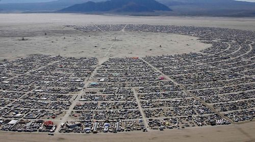

(Burning man city)

## Back to measuring economic benefit

## Total Surplus

- **Total Surplus** - Total Surplus is the value to both *consumers* and *producers* of all the transactions in a market. It is the sum of producer surplus and consumer surplus.

\[TS = PS + CS.\]

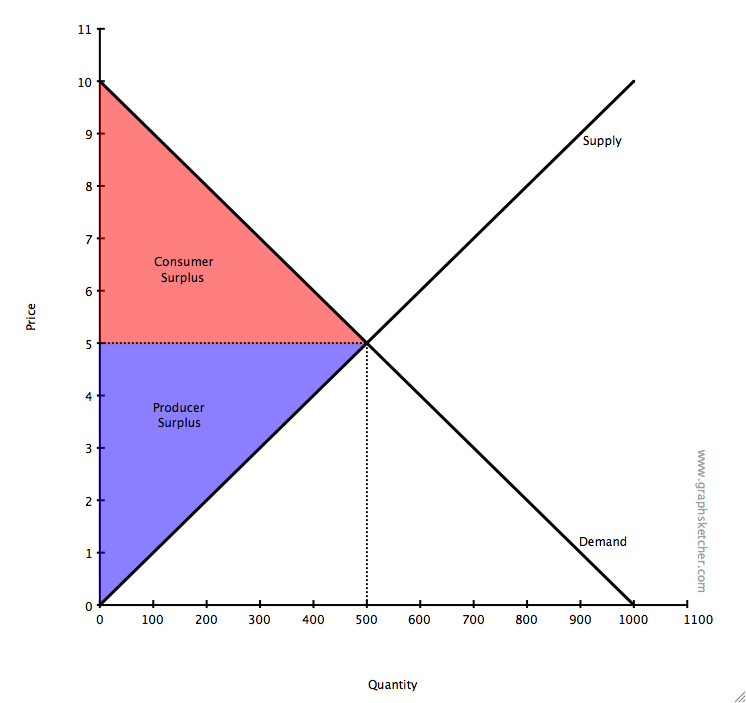

Image source.

## Larger Consumer Surplus

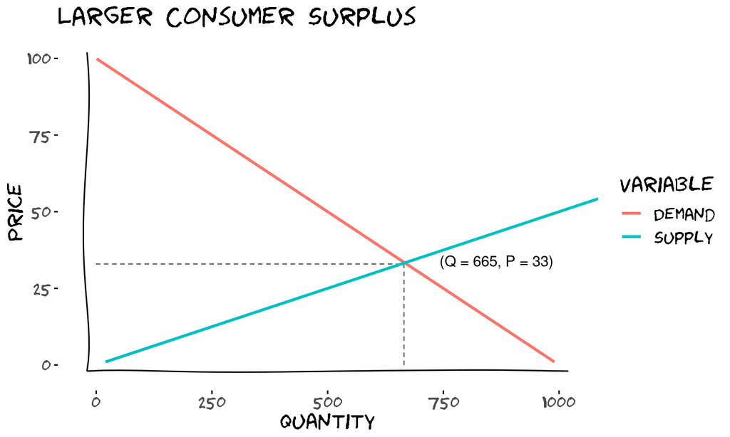

## Larger Producer Surplus

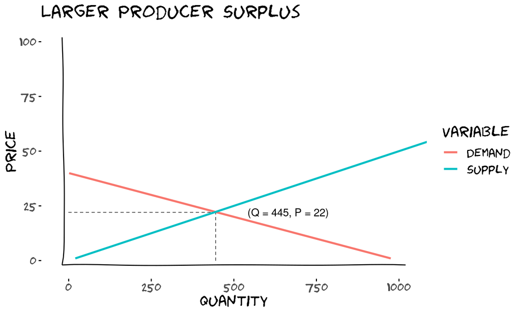

## Market Interventions

**The government could:**

- **Reallocate between consumers** - *redistribute goods from a consumer who bought it to a consumer who didn’t.*
- **Reallocate between sellers** - *redistribute goods from a producers who sells to a producer who doesn’t.*
- **Change the quantity traded** - *set a limit on the quantity sold.*
- **Set a price** - *enforce a lower or higher price.*

## When Markets Work Well

- Lots of producers and consumers (not enough sellers leads to monopoly).
- Well defined property rights (who owns what means of production, what income, etc…).
- Enough information about the goods being sold (uncertainty makes purchasing difficult).

## When Markets Don’t Work Well

- **Externalities** - *If a market transaction leads to an externality (i.e. production damages others via pollution).*
- **Poorly defined property rights** - *It’s hard to sell or buy when there’s uncertainty about ownership.*
- **Monopoly or Oligopoly** - *When there aren’t enough sellers, monopoly producers can charge excess prices.*
- **Monopsony** - *When there are only a few buyers, they can withold transcations to force producers to sell for low prices.*
- **Thinness** - *If there are not many transactions, (i.e. the market is ‘thin’) then there are opportunities for arbitrage.*

## Wrapping Up

- Complete the [knowledge check](https://goo.gl/forms/KQTEGoLhpf3dJ9jJ2) for today’s participation point.
- Please provide [feedback](https://goo.gl/forms/8SiOwdi19kN8cINJ3) on today’s lecture.